# Text Mining

## Word Clouds

Let’s look at the most common words in Jane Austen’s works as a whole again, but this time as a wordcloud. The bigger the word, the more common it is. The colors here correspond to the size and are to make the plot “pretty” - they don’t add any other information except to act as size categories.

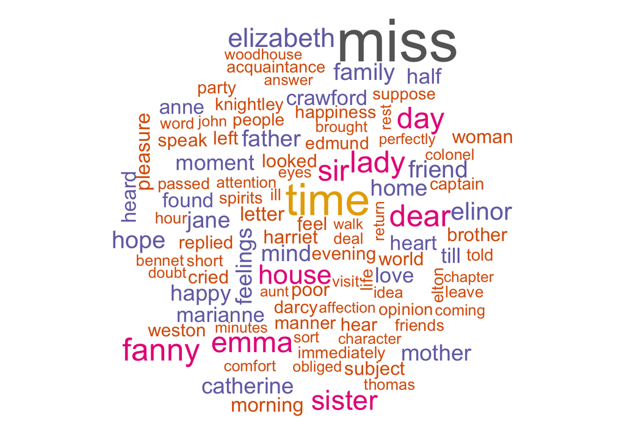

```r
tidy_books %>%
  anti_join(stop_words, by = "word") %>%
  count(word) %>%
  with(wordcloud(word, n, max.words = 100,
                 colors = brewer.pal(8, "Dark2")))
```

In other functions, such as `comparison.cloud()`, you may need to turn the data frame into a matrix with `reshape2`’s `acast()` function. Let’s do the sentiment analysis to tag positive and negative words using an inner join, then find the most common positive and negative words. Until the step where we need to send the data to `comparison.cloud()`, this can all be done with joins, piping, and dplyr because our data is in tidy format.

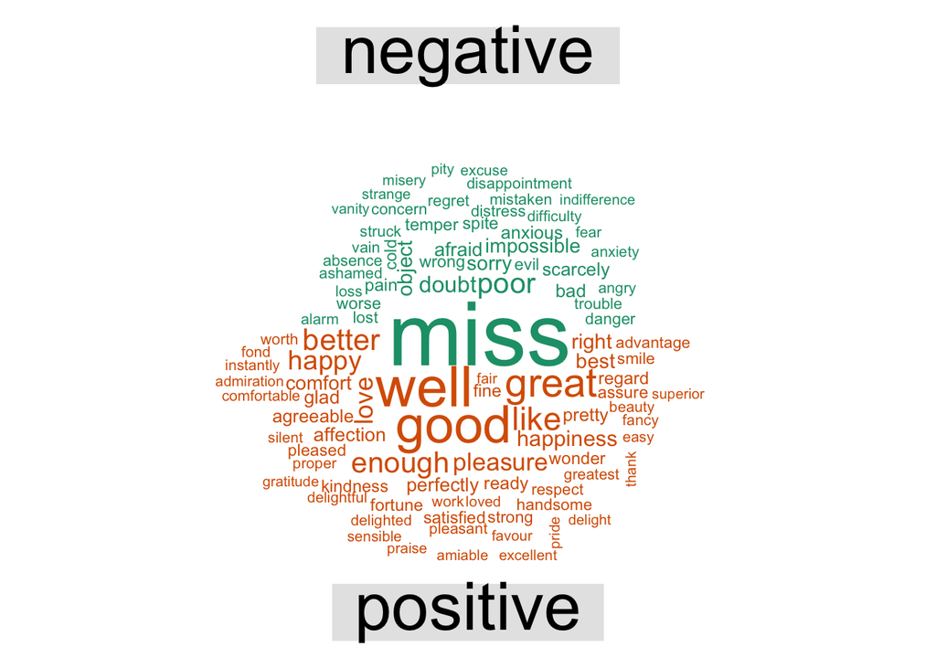

```r
tidy_books %>%
  inner_join(get_sentiments("bing"), by = "word") %>%
  count(word, sentiment, sort = TRUE) %>%
  acast(word ~ sentiment, value.var = "n", fill = 0) %>%
  comparison.cloud(max.words = 100,
                   colors = brewer.pal(8, "Dark2"))
```

Let’s make the same wordclouds for the Brontë novels.

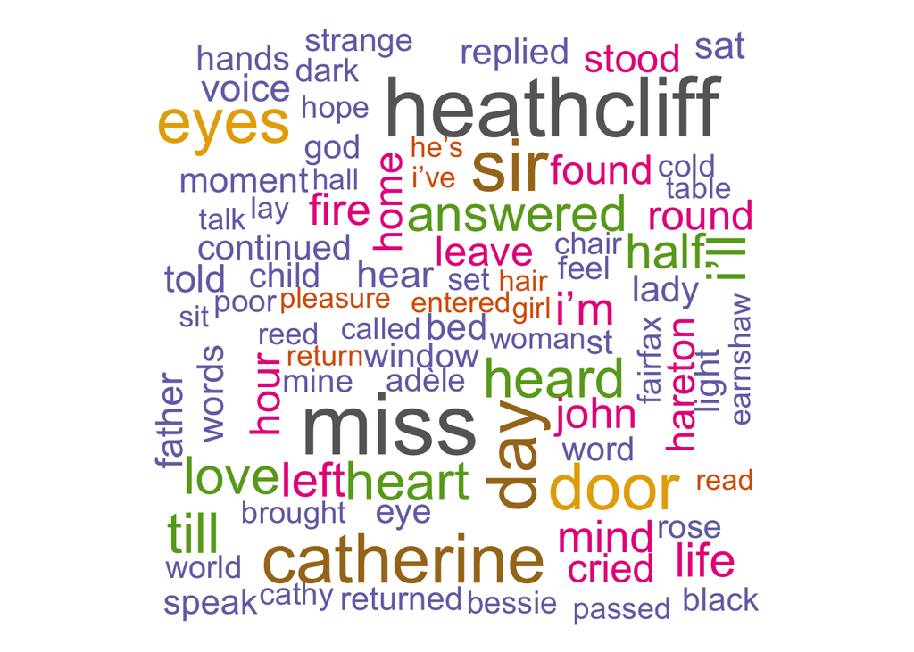

```r
tidy_bronte %>%
  anti_join(stop_words, by = "word") %>%
  count(word) %>%
  with(wordcloud(word, n, max.words = 100,
                 colors = brewer.pal(8, "Dark2")))
```

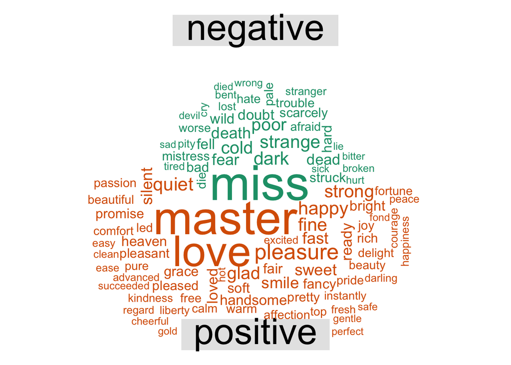

```r
tidy_bronte %>%
  inner_join(get_sentiments("bing"), by = "word") %>%
  count(word, sentiment, sort = TRUE) %>%
  acast(word ~ sentiment, value.var = "n", fill = 0) %>%
  comparison.cloud(max.words = 100,
                   colors = brewer.pal(8, "Dark2"))
```

And finally, the Dickens novels.

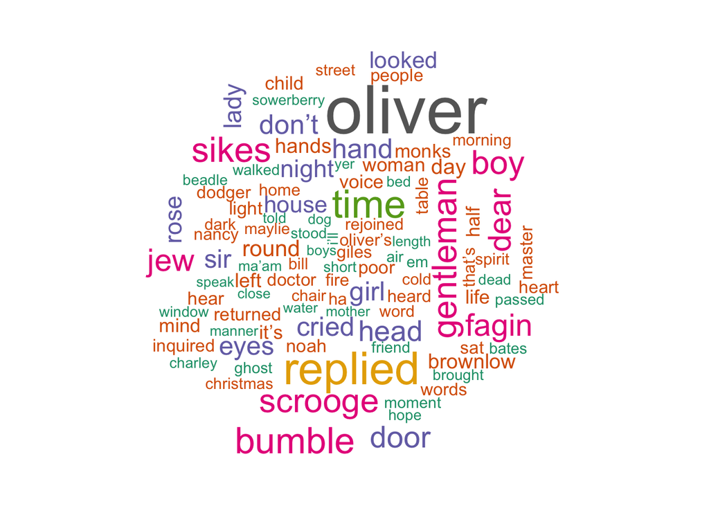

```r
tidy_dickens %>%
  anti_join(stop_words, by = "word") %>%
  count(word) %>%
  with(wordcloud(word, n, max.words = 100,
                 colors = brewer.pal(8, "Dark2")))
```

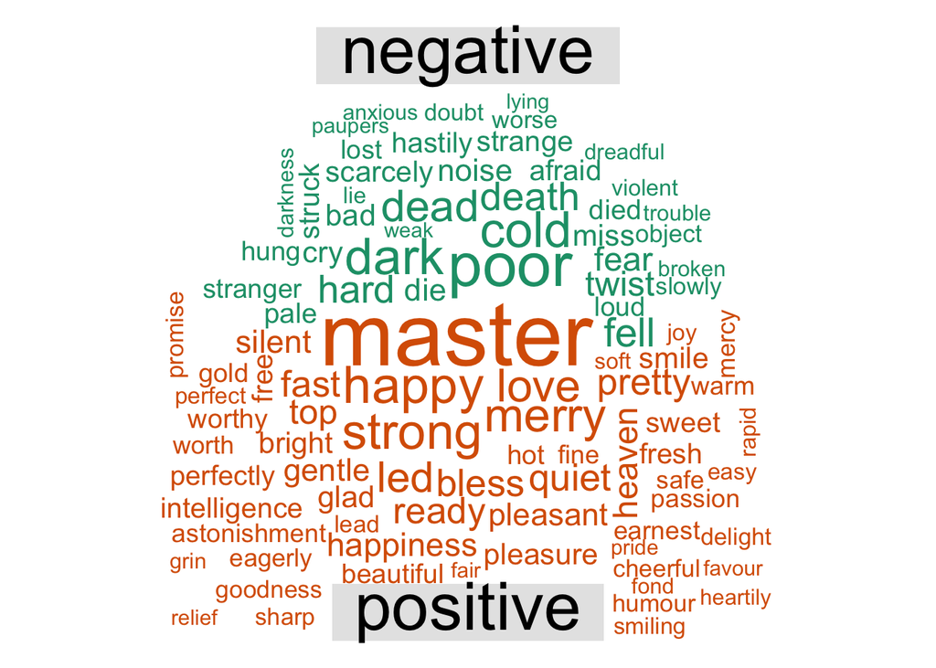

```r
tidy_dickens %>%
  inner_join(get_sentiments("bing"), by = "word") %>%
  count(word, sentiment, sort = TRUE) %>%
  acast(word ~ sentiment, value.var = "n", fill = 0) %>%
  comparison.cloud(max.words = 100,
                   colors = brewer.pal(8, "Dark2"))
```

## Word and Document Frequency: tf-idf

A central question in text mining and natural language processing is how to quantify what a document is about. Can we do this by looking at the words that make up the document? One measure of how important a word may be is its **term frequency (tf)**, how frequently a word occurs in a document. There are words in a document, however, that occur many times but may not be important. In English, these are probably words like “the”, “is”, “of”, etc. We might take the approach of adding words like these to a list of stop words and removing them before analysis, but it is possible that some of these words might be more important in some documents than others. A list of stop words is not a very sophisticated approach to adjusting term frequency for commonly used words.

Another approach is to look at a term’s **inverse document frequency (idf)**, which decreases the weight for commonly used words and increases the weight for words that are not used very much in a collection of documents. **This can be combined with term frequency to calculate a term’s tf-idf (the two quantities multiplied together), the frequency of a term adjusted for how rarely it is used**.

The statistic tf-idf is intended to measure how important a word is to a document in a collection (or corpus) of documents, for example, to one novel in a collection of novels or to one website in a collection of websites.

It is a rule-of-thumb or heuristic quantity; while it has proved useful in text mining, search engines, etc., its theoretical foundations are considered less than firm by information theory experts. The inverse document frequency for any given term is defined as

$$idf(\text{term}) = \ln\left(
\frac{n_{\text{documents}}}{n_{\text{documents containing term}}}
\right)$$

We can use tidy data principles, to approach tf-idf analysis and use consistent, effective tools to quantify how important various terms are in a document that is part of a collection.

### Term frequency

Let’s start by again looking at the published novels of Jane Austen and examine first term frequency, then tf-idf. We can start just by using `dplyr` functions such as `group_by()` and `join()`. What are the most commonly used words in Jane Austen’s novels? (Let’s also calculate the total words in each novel here, for later use.)

```r
book_words <- austen_books() %>%
  unnest_tokens(word, text) %>%
  count(book, word, sort = TRUE)

total_words <- book_words %>%
  group_by(book) %>%
  summarize(total = sum(n), .groups = "drop")

book_words <- left_join(book_words, total_words, by = "book")

book_words
```

```
## # A tibble: 40,379 × 4
##    book              word      n  total
##    <fct>             <chr> <int>  <int>
##  1 Mansfield Park    the    6206 160460
##  2 Mansfield Park    to     5475 160460
##  3 Mansfield Park    and    5438 160460
##  4 Emma              to     5239 160996
##  5 Emma              the    5201 160996
##  6 Emma              and    4896 160996
##  7 Mansfield Park    of     4778 160460
##  8 Pride & Prejudice the    4331 122204
##  9 Emma              of     4291 160996
## 10 Pride & Prejudice to     4162 122204
## # ℹ 40,369 more rows
```

There is one row in this `book_words` data frame for each word-book combination; `n` is the number of times that word is used in that book and `total` is the total words in that book. The usual suspects are here with the highest `n`, “the”, “and”, “to”, and so forth. Let’s look at the distribution of `n/total` for each novel, the number of times a word appears in a novel divided by the total number of terms (words) in that novel. This is exactly what term frequency is.

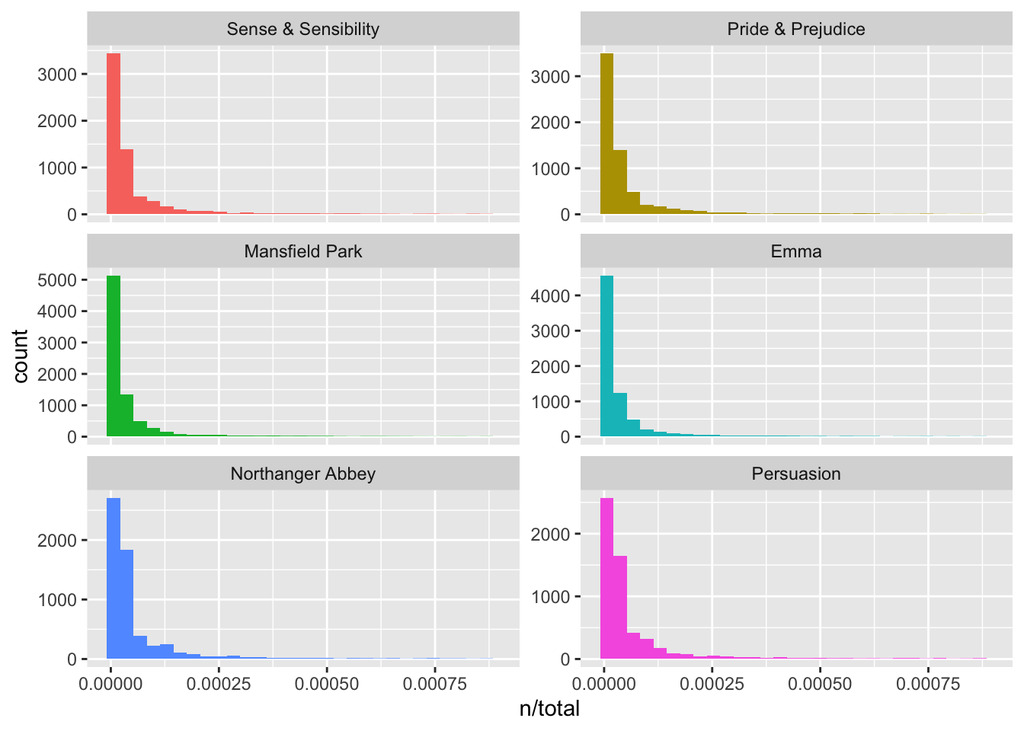

```r
ggplot(book_words, aes(n / total, fill = book)) +
  geom_histogram(show.legend = FALSE) +
  xlim(NA, 0.0009) +
  facet_wrap(~book, ncol = 2, scales = "free_y")
```

There are very long tails to the right for these novels (those extremely common words!) that we have not shown in these plots. These plots exhibit similar distributions for all the novels, with many words that occur rarely and fewer words that occur frequently.

### Zipf’s Law

Distributions like those shown above are typical in language. In fact, those types of long-tailed distributions are so common in any given corpus of natural language (like a book, or a lot of text from a website, or spoken words) that the relationship between the frequency that a word is used and its rank has been the subject of study. A classic version of this relationship is called Zipf’s law, after George Zipf, a 20th century American linguist.

**Zipf’s law states that the frequency that a word appears is inversely proportional to its rank**.

Since we have the data frame we used to plot term frequency, we can examine Zipf’s law for Jane Austen’s novels with just a few lines of dplyr functions.

```r
freq_by_rank <- book_words %>%
  group_by(book) %>%
  mutate(
    rank = row_number(),
    `term frequency` = n / total
  ) %>%
  ungroup()

freq_by_rank
```

```
## # A tibble: 40,379 × 6
##    book              word      n  total  rank `term frequency`
##    <fct>             <chr> <int>  <int> <int>            <dbl>
##  1 Mansfield Park    the    6206 160460     1           0.0387
##  2 Mansfield Park    to     5475 160460     2           0.0341
##  3 Mansfield Park    and    5438 160460     3           0.0339
##  4 Emma              to     5239 160996     1           0.0325
##  5 Emma              the    5201 160996     2           0.0323
##  6 Emma              and    4896 160996     3           0.0304
##  7 Mansfield Park    of     4778 160460     4           0.0298
##  8 Pride & Prejudice the    4331 122204     1           0.0354
##  9 Emma              of     4291 160996     4           0.0267
## 10 Pride & Prejudice to     4162 122204     2           0.0341
## # ℹ 40,369 more rows
```

The `rank` column here tells us the rank of each word within the frequency table; the table was already ordered by `n` so we could use `row_number()` to find the rank. Then, we can calculate the term frequency in the same way we did before. Zipf’s law is often visualized by plotting `rank` on the x-axis and term `frequency` on the y-axis, on logarithmic scales. Plotting this way, an inversely proportional relationship will have a constant, negative slope.

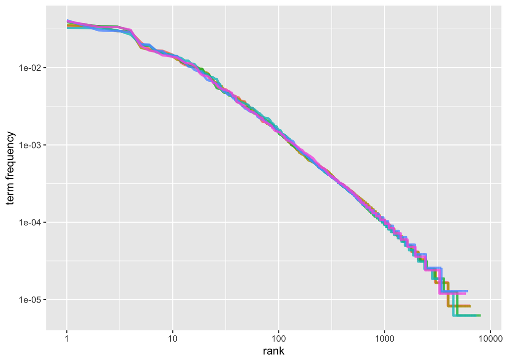

```r
freq_by_rank %>%
  ggplot(aes(rank, `term frequency`, color = book)) +
  geom_line(linewidth = 1.1, alpha = 0.8, show.legend = FALSE) +
  scale_x_log10() +
  scale_y_log10()
```

We see that all six of Jane Austen’s novels are similar to each other, and that the relationship between rank and frequency does have negative slope. It is not quite constant, though; perhaps we could view this as a broken [power law](https://en.wikipedia.org/wiki/Power_law) with, say, three sections. Let’s see what the exponent of the power law is for the middle section of the rank range.

```r
rank_subset <- freq_by_rank %>%
  filter(rank < 500, rank > 10)

lm(log10(`term frequency`) ~ log10(rank), data = rank_subset)
```

```
##
## Call:
## lm(formula = log10(`term frequency`) ~ log10(rank), data = rank_subset)
##
## Coefficients:
## (Intercept)  log10(rank)
##     -0.6226      -1.1125
```

Classic versions of Zipf’s law have
$$\text{frequency} \propto \frac{1}{\text{rank}}$$
and we have in fact gotten a slope close to -1 here. Let’s plot this fitted power law with the data to see how it looks.

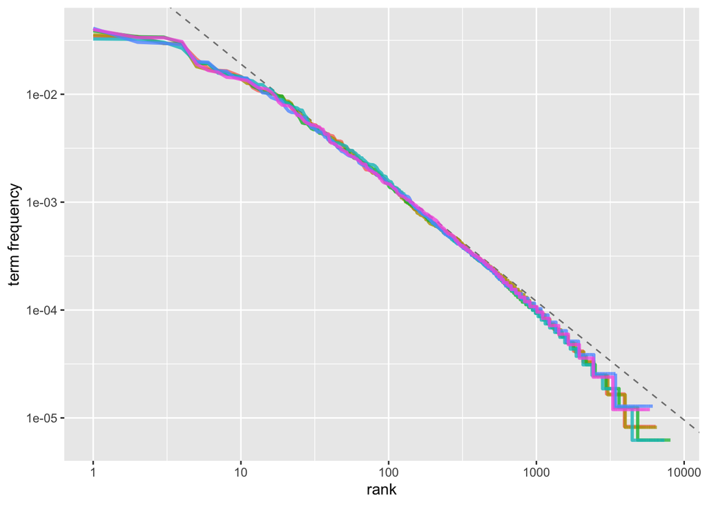

```r
freq_by_rank %>%
  ggplot(aes(rank, `term frequency`, color = book)) +
  geom_abline(
    intercept = -0.62, slope = -1.1,
    color = "gray50", linetype = 2
  ) +
  geom_line(linewidth = 1.1, alpha = 0.8, show.legend = FALSE) +
  scale_x_log10() +
  scale_y_log10()
```

We have found a result close to the classic version of Zipf’s law for the corpus of Jane Austen’s novels. The deviations we see here at high rank are not uncommon for many kinds of language; a corpus of language often contains fewer rare words than predicted by a single power law. The deviations at low rank are more unusual. Jane Austen uses a lower percentage of the most common words than many collections of language. This kind of analysis could be extended to compare authors, or to compare any other collections of text.

### The `bind_tf_idf()` function

The idea of tf-idf is to find the important words for the content of each document by decreasing the weight for commonly used words and increasing the weight for words that are not used very much in a collection or corpus of documents, in this case, the group of Jane Austen’s novels as a whole. Calculating tf-idf attempts to find the words that are important (i.e., common) in a text, but not too common. Let’s do that now.

The `bind_tf_idf()` function in the `tidytext` package takes a tidy text dataset as input with one row per token (term), per document. One column (`word` here) contains the terms/tokens, one column contains the documents (`book` in this case), and the last necessary column contains the counts, how many times each document contains each term (`n` in this example). We calculated a total for each book for our explorations in previous sections, but it is not necessary for the `bind_tf_idf()` function; the table only needs to contain all the words in each document.

```r
book_tf_idf <- book_words %>%
  bind_tf_idf(word, book, n)

book_tf_idf
```

```
## # A tibble: 40,379 × 7
##    book              word      n  total     tf   idf tf_idf
##    <fct>             <chr> <int>  <int>  <dbl> <dbl>  <dbl>
##  1 Mansfield Park    the    6206 160460 0.0387     0      0
##  2 Mansfield Park    to     5475 160460 0.0341     0      0
##  3 Mansfield Park    and    5438 160460 0.0339     0      0
##  4 Emma              to     5239 160996 0.0325     0      0
##  5 Emma              the    5201 160996 0.0323     0      0
##  6 Emma              and    4896 160996 0.0304     0      0
##  7 Mansfield Park    of     4778 160460 0.0298     0      0
##  8 Pride & Prejudice the    4331 122204 0.0354     0      0
##  9 Emma              of     4291 160996 0.0267     0      0
## 10 Pride & Prejudice to     4162 122204 0.0341     0      0
## # ℹ 40,369 more rows
```

Notice that idf and thus tf-idf are zero for these extremely common words. These are all words that appear in all six of Jane Austen’s novels, so the idf term (which will then be the natural log of 1) is zero. The inverse document frequency (and thus tf-idf) is very low (near zero) for words that occur in many of the documents in a collection; this is how this approach decreases the weight for common words. The inverse document frequency will be a higher number for words that occur in fewer of the documents in the collection.

Let’s look at terms with high tf-idf in Jane Austen’s works.

```r
book_tf_idf %>%
  select(-total) %>%
  arrange(desc(tf_idf))
```

```
## # A tibble: 40,379 × 6
##    book                word          n      tf   idf  tf_idf
##    <fct>               <chr>     <int>   <dbl> <dbl>   <dbl>
##  1 Sense & Sensibility elinor      623 0.00519  1.79 0.00931
##  2 Sense & Sensibility marianne    492 0.00410  1.79 0.00735
##  3 Mansfield Park      crawford    493 0.00307  1.79 0.00551
##  4 Pride & Prejudice   darcy       373 0.00305  1.79 0.00547
##  5 Persuasion          elliot      254 0.00304  1.79 0.00544
##  6 Emma                emma        786 0.00488  1.10 0.00536
##  7 Northanger Abbey    tilney      196 0.00252  1.79 0.00452
##  8 Emma                weston      389 0.00242  1.79 0.00433
##  9 Pride & Prejudice   bennet      294 0.00241  1.79 0.00431
## 10 Persuasion          wentworth   191 0.00228  1.79 0.00409
## # ℹ 40,369 more rows
```

Here we see all proper nouns, names that are in fact important in these novels. None of them occur in all of the novels, and they are important, characteristic words for each text within the corpus of Jane Austen’s novels.

Some of the values for idf are the same for different terms because there are 6 documents in this corpus and we are seeing the numerical value for $\ln(6/1), \ln(6/2)$, etc.

Let’s look at a visualization for these high tf-idf words.

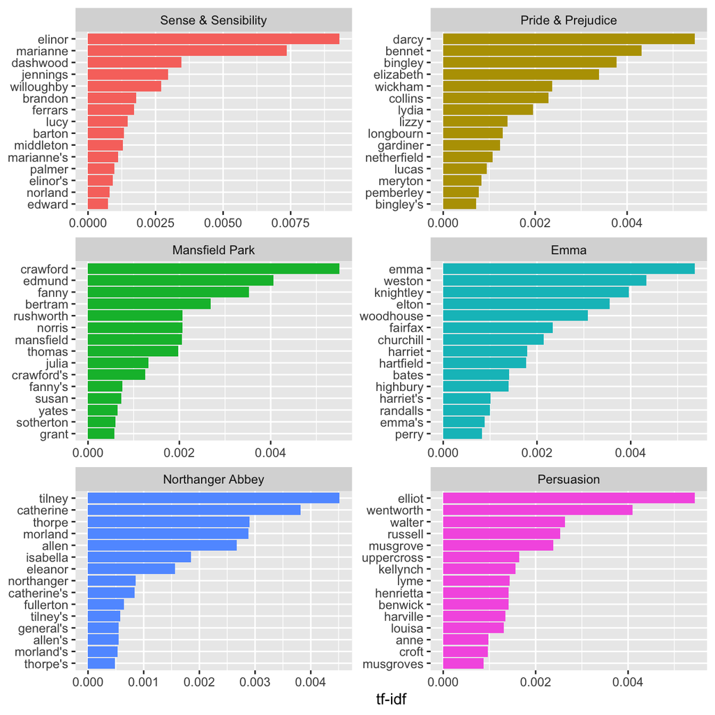

```r
book_tf_idf %>%
  group_by(book) %>%
  slice_max(tf_idf, n = 15, with_ties = FALSE) %>%
  ungroup() %>%
  ggplot(aes(tf_idf, fct_reorder(word, tf_idf), fill = book)) +
  geom_col(show.legend = FALSE) +
  facet_wrap(~book, ncol = 2, scales = "free") +
  labs(x = "tf-idf", y = NULL)
```

Still all proper nouns! These words are, as measured by tf-idf, the most important to each novel and most readers would likely agree. **What measuring tf-idf has done here is show us that Jane Austen used similar language across her six novels, and what distinguishes one novel from the rest within the collection of her works are the proper nouns, the names of people and places. This is the point of tf-idf; it identifies words that are important to one document within a collection of documents**.

## Public Health Example: Free-text Survey Responses

To connect these tools to public health practice, let’s look at a tiny synthetic example that mimics free-text responses from a patient experience survey at a community clinic. In practice, you might have hundreds or thousands of responses; here we keep it small so you can see what’s happening.

```r
ph_comments <- tibble(
  id = 1:6,
  response = c(
    "The clinic hours make it hard to come in after work.",
    "The staff were very kind and explained the vaccine side effects clearly.",
    "I am worried about sharing my immigration status when I register.",
    "The wait time was too long and the waiting room felt crowded.",
    "I appreciated that the nurse spoke my language and listened to my concerns.",
    "It was confusing to get an appointment through the new online portal."
  )
)

ph_comments
```

```
## # A tibble: 6 × 2
##      id response
##   <int> <chr>
## 1     1 The clinic hours make it hard to come in after work.
## 2     2 The staff were very kind and explained the vaccine side effects clearly.
## 3     3 I am worried about sharing my immigration status when I register.
## 4     4 The wait time was too long and the waiting room felt crowded.
## 5     5 I appreciated that the nurse spoke my language and listened to my conce…
## 6     6 It was confusing to get an appointment through the new online portal.
```

### Tidy the survey text

We convert the responses to one-token-per-row and remove stop words, just as we did for the novels.

```r
ph_tidy <- ph_comments %>%
  unnest_tokens(word, response) %>%
  anti_join(stop_words, by = "word")

ph_tidy
```

```
## # A tibble: 26 × 2
##       id word
##    <int> <chr>
##  1     1 clinic
##  2     1 hours
##  3     1 hard
##  4     2 staff
##  5     2 explained
##  6     2 vaccine
##  7     2 effects
##  8     3 worried
##  9     3 sharing
## 10     3 immigration
## # ℹ 16 more rows
```

### Sentiment for each response

We can get a rough sense of whether each comment is more positive or negative using the `bing` lexicon. We’ll compute a **net sentiment** score for each response: number of positive words minus number of negative words.

```r
ph_sentiment <- ph_tidy %>%
  inner_join(get_sentiments("bing"), by = "word") %>%
  count(id, sentiment) %>%
  pivot_wider(names_from = sentiment, values_from = n, values_fill = 0L) %>%
  mutate(net_sentiment = positive - negative)

ph_sentiment
```

```
## # A tibble: 5 × 4
##      id negative positive net_sentiment
##   <int>    <int>    <int>         <int>
## 1     1        1        0            -1
## 2     3        1        0            -1
## 3     4        1        0            -1
## 4     5        1        1             0
## 5     6        1        0            -1
```

In a real dataset you might:

- Look at how sentiment varies by clinic site, language, or time period.
- Flag very negative comments for qualitative review by the quality improvement team.

### Which words characterize each response? (tf-idf)

We can also use tf-idf to identify which words are **most distinctive** for each response. Here, each response `id` is treated as a “document” in the corpus.

```r
ph_tf_idf <- ph_tidy %>%
  count(id, word) %>%
  bind_tf_idf(word, id, n)

ph_tf_idf %>%
  arrange(desc(tf_idf))
```

```
## # A tibble: 26 × 6
##       id word          n    tf   idf tf_idf
##    <int> <chr>     <int> <dbl> <dbl>  <dbl>
##  1     1 clinic        1 0.333  1.79  0.597
##  2     1 hard          1 0.333  1.79  0.597
##  3     1 hours         1 0.333  1.79  0.597
##  4     2 effects       1 0.25   1.79  0.448
##  5     2 explained     1 0.25   1.79  0.448
##  6     2 staff         1 0.25   1.79  0.448
##  7     2 vaccine       1 0.25   1.79  0.448
##  8     4 crowded       1 0.25   1.79  0.448
##  9     4 time          1 0.25   1.79  0.448
## 10     4 wait          1 0.25   1.79  0.448
## # ℹ 16 more rows
```

Let’s visualize the top words per response:

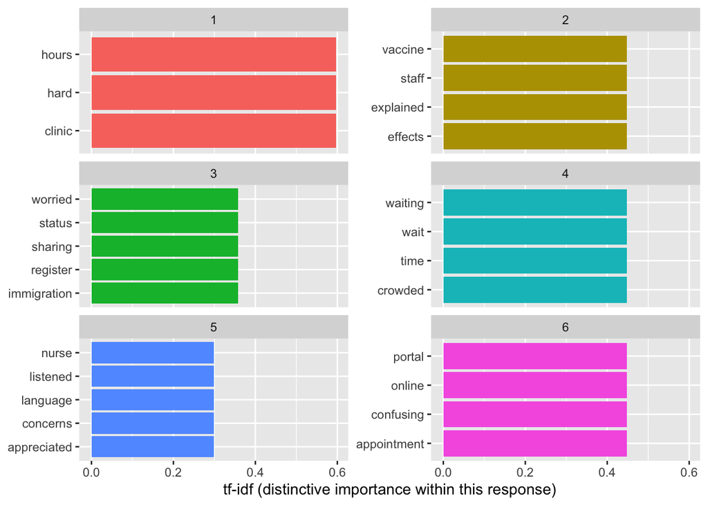

```r
ph_tf_idf %>%
  group_by(id) %>%
  slice_max(tf_idf, n = 5, with_ties = FALSE) %>%
  ungroup() %>%
  ggplot(aes(tf_idf, fct_reorder(word, tf_idf), fill = factor(id))) +
  geom_col(show.legend = FALSE) +
  facet_wrap(~id, ncol = 2, scales = "free_y") +
  labs(
    x = "tf-idf (distinctive importance within this response)",
    y = NULL
  )
```

From here, the same workflows you used on novels can be applied to:

- Open-ended survey questions (e.g., CHNA, patient experience).
- Provider notes or triage notes (with appropriate privacy safeguards).
- Public health reports, guidelines, or policy documents.